# **Multispecies Trait Data**

Fang-Kim-Lee-Reategui

# **Introduction**

This is our R Notebook, showing the steps we took to complete Project3 for CS 329E. This notebook includes step-by-step instructions on how to reproduce our project. To obtain our data, we used esapubs.org, an online ecological archive containing data sets on analyses of life history, ecological, and geographic trait differences among species. In this project, we analyze the information on traits to look at patterns among orders and species.

# **Data Description**

# **Cleaning Data**

Here’s our ETL file to clean our data set.

```r
source("../01 Data/R_ETL.pantheria.R")
```

```
Classes ‘tbl_df’, ‘tbl’ and 'data.frame':   5416 obs. of  55 variables:
 $ MSW05_Order                 : chr  "Artiodactyla" "Carnivora" "Carnivora" "Carnivora" ...
 $ MSW05_Family                : chr  "Camelidae" "Canidae" "Canidae" "Canidae" ...
 $ MSW05_Genus                 : chr  "Camelus" "Canis" "Canis" "Canis" ...
 $ MSW05_Species               : chr  "dromedarius" "adustus" "aureus" "latrans" ...
 $ MSW05_Binomial              : chr  "Camelus dromedarius" "Canis adustus" "Canis aureus" "Canis latrans" ...
 $ 1-1_ActivityCycle           : int  3 1 2 2 2 2 -999 2 3 -999 ...
 $ 5-1_AdultBodyMass_g         : num  492714 10392 9659 11989 31757 ...
 $ 8-1_AdultForearmLen_mm      : num  -999 -999 -999 -999 -999 -999 -999 -999 -999 -999 ...
 $ 13-1_AdultHeadBodyLen_mm    : num  -999 745 828 872 1055 ...
 $ 2-1_AgeatEyeOpening_d       : num  -999 -999 7.5 11.9 14 ...
 $ 3-1_AgeatFirstBirth_d       : num  1652 -999 -999 365 548 ...
 $ 18-1_BasalMetRate_mLO2hr    : num  40293 -999 -999 3699 11254 ...
 $ 5-2_BasalMetRateMass_g      : num  407000 -999 -999 10450 33100 ...
 $ 6-1_DietBreadth             : int  3 6 6 1 1 3 2 2 -999 -999 ...
 $ 7-1_DispersalAge_d          : num  -999 330 -999 255 180 ...
 $ 9-1_GestationLen_d          : num  386.5 65 61.2 61.7 63.5 ...
 $ 12-1_HabitatBreadth         : int  1 1 1 1 1 -999 -999 1 1 -999 ...
 $ 22-1_HomeRange_km2          : num  196.32 1.01 2.95 18.88 159.86 ...
 $ 22-2_HomeRange_Indiv_km2    : num  -999 1.01 3.13 19.91 43.13 ...
 $ 14-1_InterbirthInterval_d   : num  614 -999 365 365 365 ...
 $ 15-1_LitterSize             : num  0.98 4.5 3.74 5.72 4.98 1.22 1 1.22 1.01 -999 ...
 $ 16-1_LittersPerYear         : num  1 -999 -999 -999 2 1 1 1 -999 -999 ...
 $ 17-1_MaxLongevity_m         : num  480 137 192 262 354 ...
 $ 5-3_NeonateBodyMass_g       : num  36751 -999 212 200 412 ...
 $ 13-2_NeonateHeadBodyLen_mm  : num  -999 -999 -999 -999 -999 -999 -999 -999 -999 -999 ...
 $ 21-1_PopulationDensity_n/km2: num  0.98 0.74 0.22 0.25 0.01 0.54 -999 0.75 4.89 -999 ...
 $ 10-1_PopulationGrpSize      : num  11 -999 -999 -999 -999 -999 -999 21 -999 -999 ...
 $ 23-1_SexualMaturityAge_d    : num  1948 250 371 373 679 ...
 $ 10-2_SocialGrpSize          : num  10 -999 -999 -999 -999 40 110 40 2.05 -999 ...
 $ 24-1_TeatNumber             : int  -999 8 8 8 9 -999 -999 -999 -999 -999 ...
 $ 12-2_Terrestriality         : int  1 1 1 1 1 -999 -999 1 2 -999 ...
 $ 6-2_TrophicLevel            : int  1 2 2 3 3 1 1 1 -999 -999 ...
 $ 25-1_WeaningAge_d           : num  389.4 52.9 61.3 43.7 44.8 ...
 $ 5-4_WeaningBodyMass_g       : num  -999 -999 -999 -999 -999 -999 -999 -999 -999 -999 ...
 $ 13-3_WeaningHeadBodyLen_mm  : num  -999 -999 -999 -999 -999 -999 -999 -999 -999 -999 ...
 $ References                  : chr  "511;543;719;1274;1297;1594;1654;1822;1848;2655;3044" "542;543;730;1113;1297;1573;2655" "543;679;730;1113;1297;1573;2655" "367;542;543;730;1113;1297;1573;1822;2655" ...
 $ 5-5_AdultBodyMass_g_EXT     : num  -999 -999 -999 -999 -999 -999 -999 -999 -999 -999 ...
 $ 16-2_LittersPerYear_EXT     : num  -999 -999 1.1 1.1 -999 -999 -999 -999 1.05 -999 ...
 $ 5-6_NeonateBodyMass_g_EXT   : num  -999 -999 -999 -999 -999 -999 -999 -999 -999 -999 ...
```

[output cut: 116 more lines]

[output not shown]

[output not shown]

```
[1] "1-1_ActivityCycle"
```

[output not shown]

```
[1] "5-1_AdultBodyMass_g"
```

[output not shown]

```
[1] "8-1_AdultForearmLen_mm"
```

[output not shown]

```
[1] "13-1_AdultHeadBodyLen_mm"
```

[output not shown]

```
[1] "2-1_AgeatEyeOpening_d"
[1] "3-1_AgeatFirstBirth_d"
```

[output not shown]

```
[1] "18-1_BasalMetRate_mLO2hr"
```

[output not shown]

```
[1] "5-2_BasalMetRateMass_g"
[1] "6-1_DietBreadth"
```

[output not shown]

```
[1] "7-1_DispersalAge_d"
```

[output not shown]

```
[1] "9-1_GestationLen_d"
```

[output not shown]

```
[1] "12-1_HabitatBreadth"
```

[output not shown]

```
[1] "22-1_HomeRange_km2"
```

[output not shown]

```
[1] "22-2_HomeRange_Indiv_km2"
```

[output not shown]

```
[1] "14-1_InterbirthInterval_d"
```

[output not shown]

```
[1] "15-1_LitterSize"
```

[output not shown]

```
[1] "16-1_LittersPerYear"
```

[output not shown]

```
[1] "17-1_MaxLongevity_m"
```

[output not shown]

```
[1] "5-3_NeonateBodyMass_g"
```

[output not shown]

```
[1] "13-2_NeonateHeadBodyLen_mm"
```

[output not shown]

```
[1] "21-1_PopulationDensity_n/km2"
```

[output not shown]

```
[1] "10-1_PopulationGrpSize"
[1] "23-1_SexualMaturityAge_d"
```

[output not shown]

```
[1] "10-2_SocialGrpSize"
[1] "24-1_TeatNumber"
[1] "12-2_Terrestriality"
```

[output not shown]

```
[1] "6-2_TrophicLevel"
```

[output not shown]

```
[1] "25-1_WeaningAge_d"
```

[output not shown]

```
[1] "5-4_WeaningBodyMass_g"
```

[output not shown]

```
[1] "13-3_WeaningHeadBodyLen_mm"
```

[output not shown]

```
[1] "5-5_AdultBodyMass_g_EXT"
```

[output not shown]

```
[1] "16-2_LittersPerYear_EXT"
```

[output not shown]

```
[1] "5-6_NeonateBodyMass_g_EXT"
```

[output not shown]

```
[1] "5-7_WeaningBodyMass_g_EXT"
```

[output not shown]

```
[1] "26-1_GR_Area_km2"
```

[output not shown]

```
[1] "26-2_GR_MaxLat_dd"
[1] "26-3_GR_MinLat_dd"
```

[output not shown]

```
[1] "26-4_GR_MidRangeLat_dd"
```

[output not shown]

```
[1] "26-5_GR_MaxLong_dd"
```

[output not shown]

```
[1] "26-6_GR_MinLong_dd"
[1] "26-7_GR_MidRangeLong_dd"
[1] "27-1_HuPopDen_Min_n/km2"
[1] "27-2_HuPopDen_Mean_n/km2"
[1] "27-3_HuPopDen_5p_n/km2"
[1] "27-4_HuPopDen_Change"
[1] "28-1_Precip_Mean_mm"
[1] "28-2_Temp_Mean_01degC"
```

[output not shown]

```
[1] "30-1_AET_Mean_mm"
```

[output not shown]

```
[1] "30-2_PET_Mean_mm"
```

[output not shown]

```
Classes ‘tbl_df’, ‘tbl’ and 'data.frame':   5416 obs. of  55 variables:
 $ MSW05_Order                 : Factor w/ 29 levels "Afrosoricida",..: 2 3 3 3 3 2 2 2 23 23 ...
 $ MSW05_Family                : Factor w/ 153 levels "Abrocomidae",..: 17 18 18 18 18 12 12 12 117 117 ...
 $ MSW05_Genus                 : Factor w/ 1230 levels "Abditomys","Abeomelomys",..: 151 152 152 152 152 117 117 117 139 139 ...
 $ MSW05_Species               : Factor w/ 3802 levels "abae","abbreviatus",..: 979 34 290 1804 1946 1191 1362 1662 828 948 ...
 $ MSW05_Binomial              : Factor w/ 5416 levels "Abditomys latidens",..: 563 564 565 566 567 409 410 411 476 477 ...
 $ 1-1_ActivityCycle           : num  3 1 2 2 2 2 0 2 3 0 ...
 $ 5-1_AdultBodyMass_g         : num  402714 10302 659 11080 31757 ...
 $ 8-1_AdultForearmLen_mm      : num  0 0 0 0 0 0 0 0 0 0 ...
 $ 13-1_AdultHeadBodyLen_mm    : num  0 745 828 872 1055 ...
 $ 2-1_AgeatEyeOpening_d       : num  0 0 7.5 11 14 ...
 $ 3-1_AgeatFirstBirth_d       : num  1652 0 0 365 548 ...
 $ 18-1_BasalMetRate_mLO2hr    : num  40203 0 0 3600 11254 ...
 $ 5-2_BasalMetRateMass_g      : num  407000 0 0 10450 33100 ...
 $ 6-1_DietBreadth             : num  3 6 6 1 1 3 2 2 0 0 ...
 $ 7-1_DispersalAge_d          : num  0 320 0 255 180 0 0 0 0 0 ...
 $ 9-1_GestationLen_d          : num  386.5 65 61.2 61.7 63.5 ...
 $ 12-1_HabitatBreadth         : num  1 1 1 1 1 0 0 1 1 0 ...
 $ 22-1_HomeRange_km2          : num  106.32 1.01 2.05 18.88 150.86 ...
 $ 22-2_HomeRange_Indiv_km2    : num  0 1.01 3.13 10.01 43.13 ...
 $ 14-1_InterbirthInterval_d   : num  614 0 365 365 365 ...
 $ 15-1_LitterSize             : num  0.08 4.5 3.74 5.72 4.08 1.22 1 1.22 1.01 0 ...
 $ 16-1_LittersPerYear         : num  1 0 0 0 2 1 1 1 0 0 ...
 $ 17-1_MaxLongevity_m         : num  480 137 102 262 354 ...
 $ 5-3_NeonateBodyMass_g       : num  36751 0 212 200 412 ...
 $ 13-2_NeonateHeadBodyLen_mm  : num  0 0 0 0 0 0 0 0 0 0 ...
 $ 21-1_PopulationDensity_n/km2: num  0.08 0.74 0.22 0.25 0.01 0.54 0 0.75 4.8 0 ...
 $ 10-1_PopulationGrpSize      : num  11 0 0 0 0 0 0 21 0 0 ...
 $ 23-1_SexualMaturityAge_d    : num  1047 241 371 372 670 ...
 $ 10-2_SocialGrpSize          : num  10 0 0 0 0 40 110 40 2.05 0 ...
 $ 24-1_TeatNumber             : num  0 8 8 8 0 0 0 0 0 0 ...
 $ 12-2_Terrestriality         : num  1 1 1 1 1 0 0 1 2 0 ...
 $ 6-2_TrophicLevel            : num  1 2 2 3 3 1 1 1 0 0 ...
 $ 25-1_WeaningAge_d           : num  380.4 52.8 61.3 43.7 44.8 ...
 $ 5-4_WeaningBodyMass_g       : num  0 0 0 0 0 0 0 0 0 0 ...
 $ 13-3_WeaningHeadBodyLen_mm  : num  0 0 0 0 0 0 0 0 0 0 ...
 $ References                  : Factor w/ 2589 levels "-999","1;13;134;484;543;820;883;890;1154;1155;1156;1157;1158;1297;1849;2018;2151;2620;2655;3079",..: 1470 1564 1678 1152 1146 1478 1529 1513 393 1 ...
 $ 5-5_AdultBodyMass_g_EXT     : num  0 0 0 0 0 0 0 0 0 0 ...
 $ 16-2_LittersPerYear_EXT     : num  0 0 1.1 1.1 0 0 0 0 1.05 0 ...
 $ 5-6_NeonateBodyMass_g_EXT   : num  0 0 0 0 0 0 0 0 0 0 ...
```

[output cut: 174 more lines]

```
 26-2_GR_MaxLat_dd number(38,4),
 26-3_GR_MinLat_dd number(38,4),
 26-4_GR_MidRangeLat_dd number(38,4),
 26-5_GR_MaxLong_dd number(38,4),
 26-6_GR_MinLong_dd number(38,4),
 26-7_GR_MidRangeLong_dd number(38,4),
 27-1_HuPopDen_Min_n/km2 number(38,4),
 27-2_HuPopDen_Mean_n/km2 number(38,4),
 27-3_HuPopDen_5p_n/km2 number(38,4),
 27-4_HuPopDen_Change number(38,4),
 28-1_Precip_Mean_mm number(38,4),
 28-2_Temp_Mean_01degC number(38,4),
 30-1_AET_Mean_mm number(38,4),
 30-2_PET_Mean_mm number(38,4)
 );
```

# **Cleaned up Data Download**

Cleaned data can be downloaded from Data.world as a .csv file.

Hosting User: jlee Database: s-17-edv-project-3 Dataset Name: Pantheria.csv

Download Link: https://query.data.world/s/a0v5q65c7q9ft4eubeyvs8wxb

```r
source("../01 Data/Access Dataworld dv3.R")
```

[output not shown]

```
           v_0                     v_1                 v_2              v_3
 Rodentia    :2277   Muridae         : 730   Crocidura   : 172   australis:  15
 Chiroptera  :1116   Cricetidae      : 681   Myotis      : 103   thomasi  :  15
 Soricomorpha: 428   Vespertilionidae: 407   Rhinolophus :  77   macrotis :  14
 Primates    : 376   Soricidae       : 376   Sorex       :  77   major    :  14
 Carnivora   : 286   Sciuridae       : 278   Hipposideros:  67   grandis  :  11
 Artiodactyla: 240   Pteropodidae    : 186   Rattus      :  66   minor    :  11
 (Other)     : 693   (Other)         :2758   (Other)     :4854   (Other)  :5336
                   v_4            v_5              v_6                 v_7
 Abditomys latidens  :   1   Min.   :0.0000   Min.   :        0   Min.   :  0.000
 Abeomelomys sevia   :   1   1st Qu.:0.0000   1st Qu.:        0   1st Qu.:  0.000
 Abrawayaomys ruschii:   1   Median :0.0000   Median :       21   Median :  0.000
 Abrocoma bennettii  :   1   Mean   :0.5583   Mean   :   109455   Mean   :  8.769
 Abrocoma boliviensis:   1   3rd Qu.:1.0000   3rd Qu.:      244   3rd Qu.:  0.000
 Abrocoma budini     :   1   Max.   :3.0000   Max.   :154321312   Max.   :246.000
 (Other)             :5410
      v_8               v_9               v_10              v_11
 Min.   :    0.0   Min.   :  0.000   Min.   :   0.00   Min.   :     0.0
 1st Qu.:    0.0   1st Qu.:  0.000   1st Qu.:   0.00   1st Qu.:     0.0
 Median :    0.0   Median :  0.000   Median :   0.00   Median :     0.0
 Mean   :  191.5   Mean   :  1.175   Mean   :  62.88   Mean   :   194.6
 3rd Qu.:  121.8   3rd Qu.:  0.000   3rd Qu.:   0.00   3rd Qu.:     0.0
 Max.   :30480.0   Max.   :153.500   Max.   :5456.75   Max.   :113712.0

      v_12               v_13            v_14               v_15             v_16
 Min.   :     0.0   Min.   :0.000   Min.   :   0.000   Min.   :  0.00   Min.   :0.0000
 1st Qu.:     0.0   1st Qu.:0.000   1st Qu.:   0.000   1st Qu.:  0.00   1st Qu.:0.0000
 Median :     0.0   Median :0.000   Median :   0.000   Median :  0.00   Median :1.0000
 Mean   :   753.8   Mean   :1.035   Mean   :   9.642   Mean   : 26.42   Mean   :0.6562
 3rd Qu.:     0.0   3rd Qu.:2.000   3rd Qu.:   0.000   3rd Qu.:  1.24   3rd Qu.:1.0000
 Max.   :407000.0   Max.   :8.000   Max.   :5248.080   Max.   :660.00   Max.   :4.0000

      v_17               v_18                v_19              v_20
 Min.   :    0.00   Min.   :     0.00   Min.   :   0.00   Min.   : 0.000
 1st Qu.:    0.00   1st Qu.:     0.00   1st Qu.:   0.00   1st Qu.: 0.000
 Median :    0.00   Median :     0.00   Median :   0.00   Median : 0.000
 Mean   :   29.15   Mean   :    37.51   Mean   :  41.48   Mean   : 1.057
 3rd Qu.:    0.00   3rd Qu.:     0.00   3rd Qu.:   0.00   3rd Qu.: 1.410
 Max.   :77270.47   Max.   :112240.72   Max.   :2007.50   Max.   :16.800

```

[output cut: 40 more lines]

```
      v_45              v_46              v_47              v_48              v_49
 Min.   :  0.000   Min.   :   0.00   Min.   :   0.00   Min.   :   0.00   Min.   :   0.00
 1st Qu.:  8.148   1st Qu.:  10.96   1st Qu.:   0.00   1st Qu.:   4.17   1st Qu.:   0.00
 Median : 52.615   Median :  60.01   Median :   1.00   Median :  25.32   Median :   1.00
 Mean   : 57.485   Mean   :  60.43   Mean   :  12.36   Mean   :  63.50   Mean   :  14.32
 3rd Qu.:104.790   3rd Qu.: 104.74   3rd Qu.:   4.00   3rd Qu.:  68.49   3rd Qu.:   8.00
 Max.   :180.000   Max.   :1004.00   Max.   :1110.00   Max.   :2060.50   Max.   :1110.00

      v_50               v_51             v_52             v_53              v_54
 Min.   :0.000000   Min.   :  0.00   Min.   :  0.00   Min.   :   0.00   Min.   :   0.0
 1st Qu.:0.007697   1st Qu.: 20.76   1st Qu.: 61.64   1st Qu.:  58.64   1st Qu.: 516.1
 Median :0.080000   Median : 80.82   Median :188.54   Median : 705.04   Median :1342.1
 Mean   :0.080633   Mean   : 95.12   Mean   :153.33   Mean   : 723.33   Mean   :1054.9
 3rd Qu.:0.120000   3rd Qu.:150.29   3rd Qu.:238.05   3rd Qu.:1269.03   3rd Qu.:1562.4
 Max.   :8.550050   Max.   :461.00   Max.   :350.00   Max.   :1858.56   Max.   :2107.0
```

|  | v_0 | v_1 | v_2 | v_3 | v_4 | v_5 | v_6 | v_7 | v_8 | v_9 | v_10 | v_11 | v_12 | v_13 | v_14 | v_15 | v_16 | v_17 | v_18 | v_19 | v_20 | v_21 | v_22 | v_23 | v_24 | v_25 | v_26 | v_27 | v_28 | … |
| --- | --- | --- | --- | --- | --- | --- | --- | --- | --- | --- | --- | --- | --- | --- | --- | --- | --- | --- | --- | --- | --- | --- | --- | --- | --- | --- | --- | --- | --- | --- |
| 1 | Artiodactyla | Camelidae | Camelus | dromedarius | Camelus dromedarius | 3 | 402714.47 | 0 | 0.00 | 0 | 1651.62 | 40203 | 407000 | 3 | 0 | 386.51 | 1 | 106.32 | 0.00 | 614.41 | 0.08 | 1 | 480 | 36751.1 | 0 | 0.08 | 11 | 1047.04 | 10 | … |
| 2 | Carnivora | Canidae | Canis | adustus | Canis adustus | 1 | 10302.40 | 0 | 745.32 | 0 | 0.00 | 0 | 0 | 6 | 320 | 65.00 | 1 | 1.01 | 1.01 | 0.00 | 4.50 | 0 | 137 | 0.0 | 0 | 0.74 | 0 | 240.88 | 0 | … |
| 3 | Primates | Pitheciidae | Callicebus | donacophilus | Callicebus donacophilus | 3 | 807.67 | 0 | 0.00 | 0 | 0.00 | 0 | 0 | 0 | 0 | 0.00 | 1 | 0.00 | 0.00 | 0.00 | 1.02 | 0 | 0 | 0.0 | 0 | 0.00 | 0 | 0.00 | 1 | … |
| 4 | Rodentia | Cricetidae | Calomys | expulsus | Calomys expulsus | 0 | 30.86 | 0 | 0.00 | 0 | 0.00 | 0 | 0 | 0 | 0 | 0.00 | 0 | 0.00 | 0.00 | 0.00 | 0.00 | 0 | 0 | 0.0 | 0 | 1105.70 | 0 | 0.00 | 0 | … |
| 5 | Soricomorpha | Soricidae | Crocidura | voi | Crocidura voi | 0 | 0.00 | 0 | 0.00 | 0 | 0.00 | 0 | 0 | 0 | 0 | 0.00 | 0 | 0.00 | 0.00 | 0.00 | 0.00 | 0 | 0 | 0.0 | 0 | 0.00 | 0 | 0.00 | 0 | … |
| 6 | Soricomorpha | Soricidae | Crocidura | vorax | Crocidura vorax | 0 | 0.00 | 0 | 0.00 | 0 | 0.00 | 0 | 0 | 0 | 0 | 0.00 | 0 | 0.00 | 0.00 | 0.00 | 0.00 | 0 | 0 | 0.0 | 0 | 0.00 | 0 | 0.00 | 0 | … |

|  | v_0 | v_1 | v_2 | v_3 | v_4 | v_5 | v_6 | v_7 | v_8 | v_9 | v_10 | v_11 | v_12 | v_13 | v_14 | v_15 | v_16 | v_17 | v_18 | v_19 | v_20 | v_21 | v_22 | v_23 | v_24 | v_25 | v_26 | v_27 | v_28 | … |
| --- | --- | --- | --- | --- | --- | --- | --- | --- | --- | --- | --- | --- | --- | --- | --- | --- | --- | --- | --- | --- | --- | --- | --- | --- | --- | --- | --- | --- | --- | --- |
| 1 | Artiodactyla | Camelidae | Camelus | dromedarius | Camelus dromedarius | 3 | 402714.47 | 0.00 | 0.00 | 0.00 | 1651.62 | 40203.00 | 407000.00 | 3 | 0.00 | 386.51 | 1 | 106.320000 | 0.000000 | 614.41 | 0.08 | 1.00 | 480.00 | 36751.10 | 0.00 | 0.08000 | 11.00 | 1047.04 | 10.00 | … |
| 2 | Carnivora | Canidae | Canis | adustus | Canis adustus | 1 | 10302.40 | 0.00 | 745.32 | 0.00 | 0.00 | 0.00 | 0.00 | 6 | 320.00 | 65.00 | 1 | 1.010000 | 1.010000 | 0.00 | 4.50 | 0.00 | 137.00 | 0.00 | 0.00 | 0.74000 | 0.00 | 240.88 | 0.00 | … |
| 3 | Primates | Pitheciidae | Callicebus | donacophilus | Callicebus donacophilus | 3 | 807.67 | 0.00 | 0.00 | 0.00 | 0.00 | 0.00 | 0.00 | 0 | 0.00 | 0.00 | 1 | 0.000000 | 0.000000 | 0.00 | 1.02 | 0.00 | 0.00 | 0.00 | 0.00 | 0.00000 | 0.00 | 0.00 | 1.00 | … |
| 4 | Rodentia | Cricetidae | Calomys | expulsus | Calomys expulsus | 0 | 30.86 | 0.00 | 0.00 | 0.00 | 0.00 | 0.00 | 0.00 | 0 | 0.00 | 0.00 | 0 | 0.000000 | 0.000000 | 0.00 | 0.00 | 0.00 | 0.00 | 0.00 | 0.00 | 1105.69995 | 0.00 | 0.00 | 0.00 | … |
| 5 | Soricomorpha | Soricidae | Crocidura | voi | Crocidura voi | 0 | 0.00 | 0.00 | 0.00 | 0.00 | 0.00 | 0.00 | 0.00 | 0 | 0.00 | 0.00 | 0 | 0.000000 | 0.000000 | 0.00 | 0.00 | 0.00 | 0.00 | 0.00 | 0.00 | 0.00000 | 0.00 | 0.00 | 0.00 | … |
| 6 | Soricomorpha | Soricidae | Crocidura | vorax | Crocidura vorax | 0 | 0.00 | 0.00 | 0.00 | 0.00 | 0.00 | 0.00 | 0.00 | 0 | 0.00 | 0.00 | 0 | 0.000000 | 0.000000 | 0.00 | 0.00 | 0.00 | 0.00 | 0.00 | 0.00 | 0.00000 | 0.00 | 0.00 | 0.00 | … |
| 7 | Soricomorpha | Soricidae | Crocidura | vosmaeri | Crocidura vosmaeri | 0 | 0.00 | 0.00 | 0.00 | 0.00 | 0.00 | 0.00 | 0.00 | 0 | 0.00 | 0.00 | 0 | 0.000000 | 0.000000 | 0.00 | 0.00 | 0.00 | 0.00 | 0.00 | 0.00 | 0.00000 | 0.00 | 0.00 | 0.00 | … |
| 8 | Soricomorpha | Soricidae | Crocidura | watasei | Crocidura watasei | 0 | 0.00 | 0.00 | 0.00 | 0.00 | 0.00 | 0.00 | 0.00 | 0 | 0.00 | 0.00 | 0 | 0.000000 | 0.000000 | 0.00 | 0.00 | 0.00 | 0.00 | 0.00 | 0.00 | 0.00000 | 0.00 | 0.00 | 0.00 | … |
| 9 | Soricomorpha | Soricidae | Crocidura | whitakeri | Crocidura whitakeri | 0 | 5.58 | 0.00 | 61.20 | 0.00 | 0.00 | 0.00 | 0.00 | 0 | 0.00 | 0.00 | 0 | 0.000000 | 0.000000 | 0.00 | 0.00 | 0.00 | 0.00 | 0.00 | 0.00 | 0.00000 | 0.00 | 0.00 | 0.00 | … |
| 10 | Soricomorpha | Soricidae | Crocidura | wimmeri | Crocidura wimmeri | 0 | 23.50 | 0.00 | 0.00 | 0.00 | 0.00 | 0.00 | 0.00 | 0 | 0.00 | 0.00 | 0 | 0.000000 | 0.000000 | 0.00 | 0.00 | 0.00 | 0.00 | 0.00 | 0.00 | 0.00000 | 0.00 | 0.00 | 0.00 | … |

[output cut: 990 more lines]

# **Tableau Generated Visualizations**

**Descriptions:** Refer to visualization captions for individual descriptions.

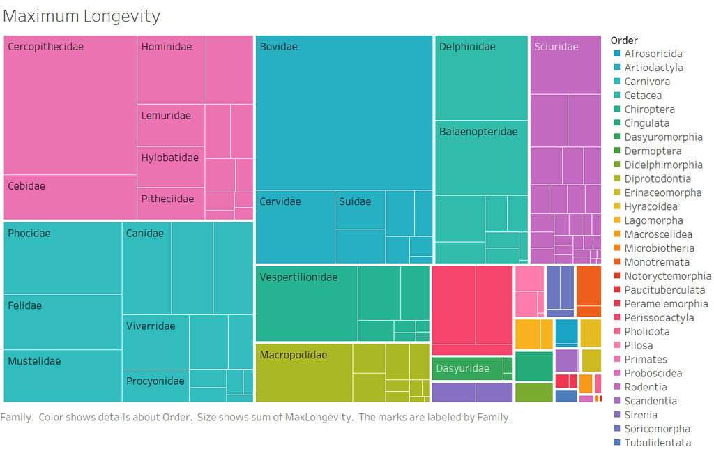

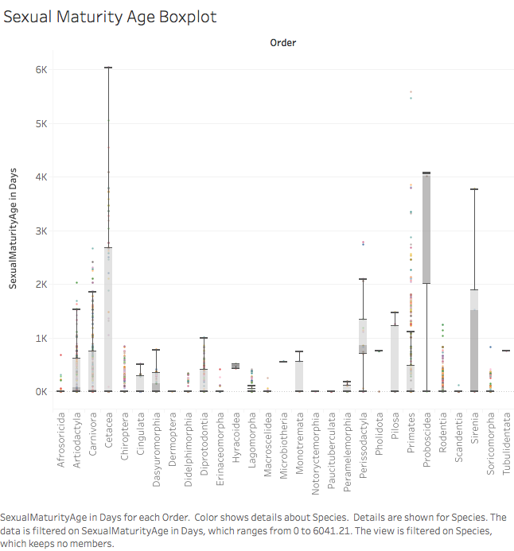

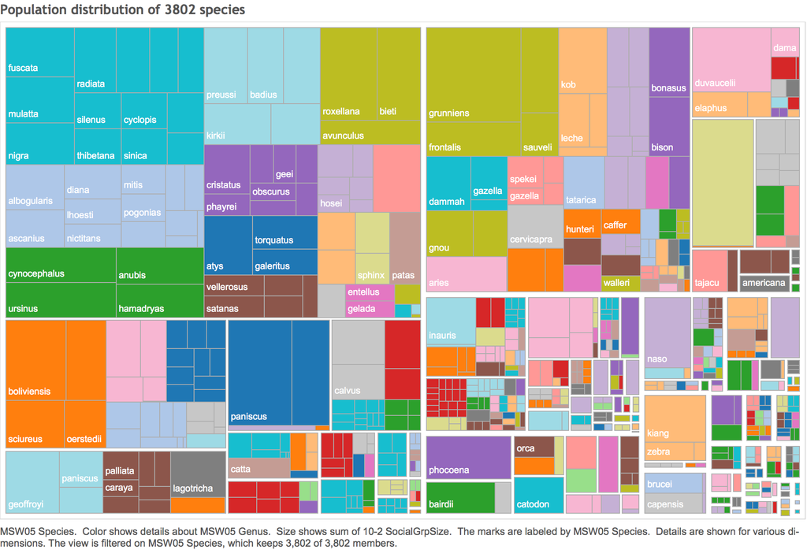